# Methylation_Mark_Analysis

HM Putnam

2024-08-26

```r
library(tidyverse)
library(ggsci)
```

5 methyl cytosine 5mC Quantitifcation Kit: Methylflash Methylated DNA quantificiation Kit (Fluorometric) (Reference: P-1035) https://www.epigentek.com/docs/P-1035.pdf

Relative Quantification: To determine the relative methylation status of two different DNA samples, simple calculation for percentage of 5-mC in total DNA can be carried out using the following formula:

Relative %5mC = ((Sample RFU - MF3 RFU)/ input DNA ng) / ((MF4 RFU - MF3 RFU)x 2 /amount of input positive control (MF4) in ng)

S is the amount of input sample DNA in ng. P is the amount of input positive control (MF4) in ng.

Acropora hyacinthus

```r
ahya <- read.csv("RAnalysis/data/Ahyacinthus_5mC.csv",  na.strings = "NA")

str(ahya)
```

```
## 'data.frame':    114 obs. of  9 variables:
##  $ Stage         : chr  "Sperm" "Sperm" "Sperm" "Oocytes" ...
##  $ Development   : chr  "Sperm" "Sperm" "Sperm" "Oocytes" ...
##  $ HPF           : chr  "0" "0" "0" "0" ...
##  $ Species       : chr  "A. hyacinthus" "A. hyacinthus" "A. hyacinthus" "A. hyacinthus" ...
##  $ Mark          : chr  "5mC" "5mC" "5mC" "5mC" ...
##  $ Temperature   : chr  "27" "27" "27" "27" ...
##  $ Replicate.Bio : chr  "Rep1" "Rep2" "Rep3" "Rep1" ...
##  $ Fluoro.530.590: int  326 781 624 1258 1108 958 1333 1071 1351 412 ...
##  $ DNA.ng        : int  149 297 301 100 100 100 100 100 100 100 ...
```

```r
as.numeric
```

```
## function (x, ...)  .Primitive("as.double")
```

```r
stnds <- ahya %>% filter(Species=="Standard") %>%
  group_by(Stage) %>%
  summarize(mean.RFU=mean(Fluoro.530.590))

ahya <- ahya %>% filter(Species=="A. hyacinthus")

MF3.RFU.ahya <- stnds$mean.RFU[[1]]
MF4.RFU.ahya <- stnds$mean.RFU[[2]]
MF4.ng.ahya <- 10

ahya$rel.percent.5mC <- (((ahya$Fluoro.530.590 -MF3.RFU.ahya )/ ahya$DNA.ng) / ((MF4.RFU.ahya - MF3.RFU.ahya)* 2 /MF4.ng.ahya))*100

ahya.27 <- ahya %>%
filter(Temperature ==27)
```

Acropora cytherea

```r
acyth <- read.csv("RAnalysis/data/Acytherea_5mC.csv",  na.strings = "NA")

str(acyth)
```

```
## 'data.frame':    72 obs. of  9 variables:
##  $ Stage         : chr  "Sperm" "Sperm" "Sperm" "Oocytes" ...
##  $ Development   : chr  "Sperm" "Sperm" "Sperm" "Oocytes" ...
##  $ HPF           : chr  "0" "" "" "" ...
##  $ Species       : chr  "A. cytherea" "A. cytherea" "A. cytherea" "A. cytherea" ...
##  $ Mark          : chr  "5mC" "5mC" "5mC" "5mC" ...
##  $ Temperature   : chr  "27" "27" "27" "27" ...
##  $ Replicate.Bio : chr  "Rep1" "Rep2" "Rep3" "Rep1" ...
##  $ Fluoro.530.590: int  553 746 843 46 32 33 89 140 64 75 ...
##  $ DNA.ng        : int  156 114 140 152 122 94 111 99 84 100 ...
```

```r
as.numeric
```

```
## function (x, ...)  .Primitive("as.double")
```

```r
stnds <- acyth %>% filter(Species=="Standard") %>%
  group_by(Stage) %>%
  summarize(mean.RFU=mean(Fluoro.530.590))

acyth <- acyth %>% filter(Species=="A. cytherea")

MF3.RFU.acyth <- stnds$mean.RFU[[1]]
MF4.RFU.acyth <- stnds$mean.RFU[[2]]
MF4.ng.acyth <- 10

acyth$rel.percent.5mC <- (((acyth$Fluoro.530.590 -MF3.RFU.acyth )/ acyth$DNA.ng) / ((MF4.RFU.acyth - MF3.RFU.acyth)* 2 /MF4.ng.acyth))*100

acyth <- acyth %>%
filter(Temperature ==27)
```

Acropora retusa

```r
aret <- read.csv("RAnalysis/data/Aretusa_5mC.csv",  na.strings = "NA")

str(aret)
```

```
## 'data.frame':    98 obs. of  9 variables:
##  $ Stage         : chr  "Sperm" "Sperm" "Sperm" "Sperm" ...
##  $ Development   : chr  "Sperm" "Sperm" "Sperm" "Sperm" ...
##  $ HPF           : chr  "0" "0" "0" "0" ...
##  $ Species       : chr  "A. retusa" "A. retusa" "A. retusa" "A. retusa" ...
##  $ Mark          : chr  "5mC" "5mC" "5mC" "5mC" ...
##  $ Temperature   : int  27 27 27 27 27 27 27 27 27 27 ...
##  $ Replicate.Bio : chr  "Rep1" "Rep2" "Rep3" "Rep4" ...
##  $ Fluoro.530.590: int  153 163 321 359 273 250 484 616 439 422 ...
##  $ DNA.ng        : int  116 124 143 143 76 102 100 100 96 96 ...
```

```r
as.numeric
```

```
## function (x, ...)  .Primitive("as.double")
```

```r
stnds <- aret %>% filter(Species=="Standard") %>%
  group_by(Stage) %>%
  summarize(mean.RFU=mean(Fluoro.530.590))

aret <- aret %>% filter(Species=="A. retusa")

MF3.RFU.aret <- stnds$mean.RFU[[1]]
MF4.RFU.aret <- stnds$mean.RFU[[2]]
MF4.ng.aret <- 10

aret$rel.percent.5mC <- (((aret$Fluoro.530.590 -MF3.RFU.aret )/ aret$DNA.ng) / ((MF4.RFU.aret - MF3.RFU.aret)* 2 /MF4.ng.aret))*100

aret <- aret %>%
filter(Temperature ==27) %>%
filter(!Stage == "Stage 12")
```

Acropora pulchra

```r
apul <- read.csv("RAnalysis/data/Apulchra_5mC.csv",  na.strings = "NA")

str(apul)
```

```
## 'data.frame':    75 obs. of  9 variables:
##  $ Stage         : chr  "Sperm" "Sperm" "Sperm" "Oocytes" ...
##  $ Development   : chr  "Sperm" "Sperm" "Sperm" "Oocytes" ...
##  $ HPF           : chr  "0" "0" "0" "0" ...
##  $ Species       : chr  "A. pulchra" "A. pulchra" "A. pulchra" "A. pulchra" ...
##  $ Mark          : chr  "5mC" "5mC" "5mC" "5mC" ...
##  $ Temperature   : int  27 27 27 27 27 27 27 27 27 27 ...
##  $ Replicate.Bio : chr  "Rep1" "Rep2" "Rep3" "Rep1" ...
##  $ Fluoro.530.590: int  335 431 418 295 43 45 44 43 46 52 ...
##  $ DNA.ng        : int  104 128 128 116 116 96 123 115 123 112 ...
```

```r
stnds <- apul %>% filter(Species=="Standard") %>%
  group_by(Stage) %>%
  summarize(mean.RFU=mean(Fluoro.530.590))

apul <- apul %>% filter(Species=="A. pulchra")

MF3.RFU.apul <- stnds$mean.RFU[[1]]
MF4.RFU.apul <- stnds$mean.RFU[[2]]
MF4.ng.apul <- 10

apul$rel.percent.5mC <- (((apul$Fluoro.530.590 -MF3.RFU.apul )/ apul$DNA.ng) / ((MF4.RFU.apul - MF3.RFU.apul)* 2 /MF4.ng.apul))*100

apul <- apul %>%
filter(Temperature ==27)
```

```r
#examine only 27

all.species.5mC <- rbind(ahya.27, acyth, aret,  apul)
unique(all.species.5mC$Stage)
```

```
##  [1] "Sperm"      "Oocytes"    "Stage 1 "   "Stage 2"    "Stage 3"
##  [6] "Stage 4"    "Stage 5"    "Stage 6"    "Stage 7"    "Stage 8"
## [11] "Stage 9"    "Stage 10"   "Stage 11"   "Stage 12"   "Stage 13"
## [16] "Stage 14"   "Stage 15"   "Stage 16"   "Stage 17"   "Stage 17.5"
## [21] "Stage 5.5"  "Stage 7.5"
```

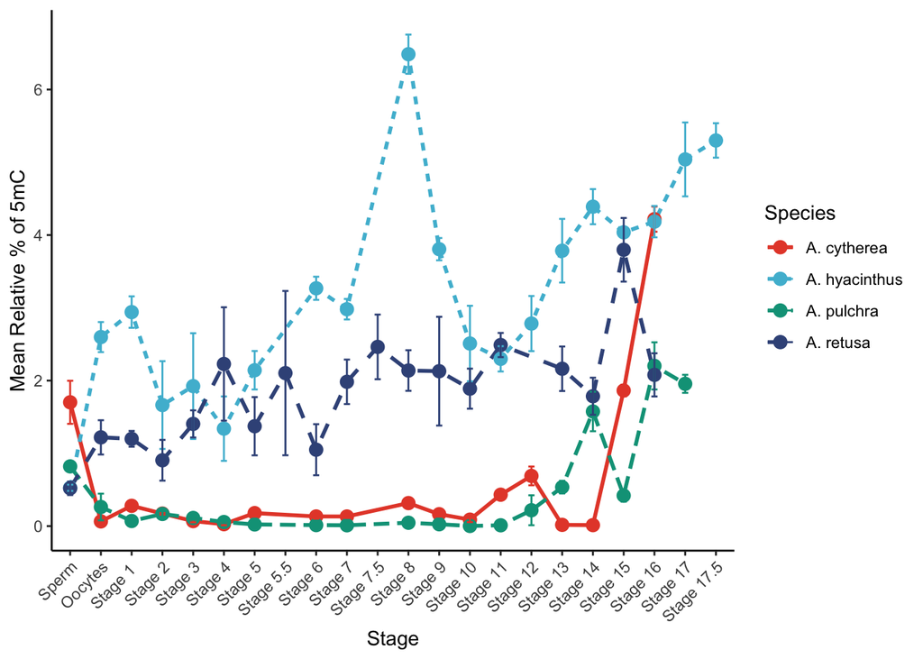

```r
devo.27 <- all.species.5mC %>%
  mutate(Stage = fct_relevel(Stage, "Sperm",      "Oocytes",   "Stage 1 ",   "Stage 2",
                             "Stage 3",    "Stage 4",    "Stage 5", "Stage 5.5",    "Stage 6",   "Stage 7",
                             "Stage 7.5", "Stage 8",    "Stage 9",    "Stage 10",   "Stage 11",   "Stage 12",
                             "Stage 13",   "Stage 14",  "Stage 15",   "Stage 16",   "Stage 17",   "Stage 17.5"))

summary_stats.devo.27 <- devo.27 %>%
  group_by(Species, Stage, Development) %>%
  summarize(
    mean_5mC = mean(rel.percent.5mC, na.rm = TRUE),
    sem_5mC = sd(rel.percent.5mC, na.rm = TRUE) / sqrt(n()),
    .groups = 'drop'
  )

summary_stats.devo.27 %>%
  ggplot(aes(x = Stage, y = mean_5mC, group = Species, color = Species)) +
  geom_line(aes(linetype = Species), size = 1) +  # Line connecting mean points
  geom_point(size = 3) +  # Mean points
  geom_errorbar(aes(ymin = mean_5mC - sem_5mC, ymax = mean_5mC + sem_5mC), width = 0.2) +  # SEM bars
  labs(
    x = "Stage",
    y = "Mean Relative % of 5mC"
  ) +
  scale_color_npg()+
  scale_fill_npg()+
  theme_classic() +
  theme(axis.text.x = element_text(angle = 45, hjust = 1))  # Rotate x-axis labels for better readability
```

Reduce to commonly sampled timepoints and analyze with ANOVA

```r
devo.27.stages <- devo.27 %>%
  filter(!Stage == "Stage 5.5") %>%
  filter(!Stage == "Stage 7.5") %>%
  filter(!Stage == "Stage 12")%>%
  filter(!Stage == "Stage 17")%>%
  filter(!Stage == "Stage 17.5")

str(devo.27.stages)
```

```
## 'data.frame':    221 obs. of  10 variables:
##  $ Stage          : Factor w/ 22 levels "Sperm","Oocytes",..: 1 1 1 2 2 2 3 3 3 4 ...
##  $ Development    : chr  "Sperm" "Sperm" "Sperm" "Oocytes" ...
##  $ HPF            : chr  "0" "0" "0" "0" ...
##  $ Species        : chr  "A. hyacinthus" "A. hyacinthus" "A. hyacinthus" "A. hyacinthus" ...
##  $ Mark           : chr  "5mC" "5mC" "5mC" "5mC" ...
##  $ Temperature    : chr  "27" "27" "27" "27" ...
##  $ Replicate.Bio  : chr  "Rep1" "Rep2" "Rep3" "Rep1" ...
##  $ Fluoro.530.590 : int  326 781 624 1258 1108 958 1333 1071 1351 412 ...
##  $ DNA.ng         : int  149 297 301 100 100 100 100 100 100 100 ...
##  $ rel.percent.5mC: num  0.49 0.612 0.479 2.956 2.598 ...
```

```r
devo.27.stages$Species <- as.factor(devo.27.stages$Species)

unique(devo.27.stages$Stage)
```

```
##  [1] Sperm    Oocytes  Stage 1  Stage 2  Stage 3  Stage 4  Stage 5  Stage 6
##  [9] Stage 7  Stage 8  Stage 9  Stage 10 Stage 11 Stage 13 Stage 14 Stage 15
## [17] Stage 16
## 22 Levels: Sperm Oocytes Stage 1  Stage 2 Stage 3 Stage 4 Stage 5 ... Stage 17.5
```

```r
unique(devo.27.stages$Development)
```

```
##  [1] "Sperm"             "Oocytes"           "Fertilized oocyte"
##  [4] "4 cells"           "8 cells"           "Morula"
##  [7] "Prawn Chip"        "Blastula"          "Late Blastula"
## [10] "Early Bowl"        "Bowl"              "Blastulation end"
## [13] "Gastrula"          "Early tear drop"   "Tear drop"
## [16] "Late tear drop"    "Early elongated"
```

```r
devo.27.stages <- devo.27.stages %>%
  mutate(Development = fct_relevel(Development, "Sperm", "Oocytes", "Fertilized oocyte", "4 cells", "8 cells", "Morula",          "Prawn Chip", "Blastula", "Late Blastula", "Early Bowl", "Bowl", "Blastulation end", "Gastrula", "Early tear drop",
"Tear drop", "Late tear drop", "Early elongated"))

stage.5mC.res <- aov(log10(rel.percent.5mC) ~ Stage*Species, data= devo.27.stages)
summary(stage.5mC.res)
```

```
##                Df Sum Sq Mean Sq F value Pr(>F)
## Stage          16  19.59   1.225   29.05 <2e-16 ***
## Species         3  85.79  28.595  678.45 <2e-16 ***
## Stage:Species  48  48.46   1.010   23.95 <2e-16 ***
## Residuals     152   6.41   0.042
## ---
## Signif. codes:  0 '***' 0.001 '**' 0.01 '*' 0.05 '.' 0.1 ' ' 1
## 1 observation deleted due to missingness
```

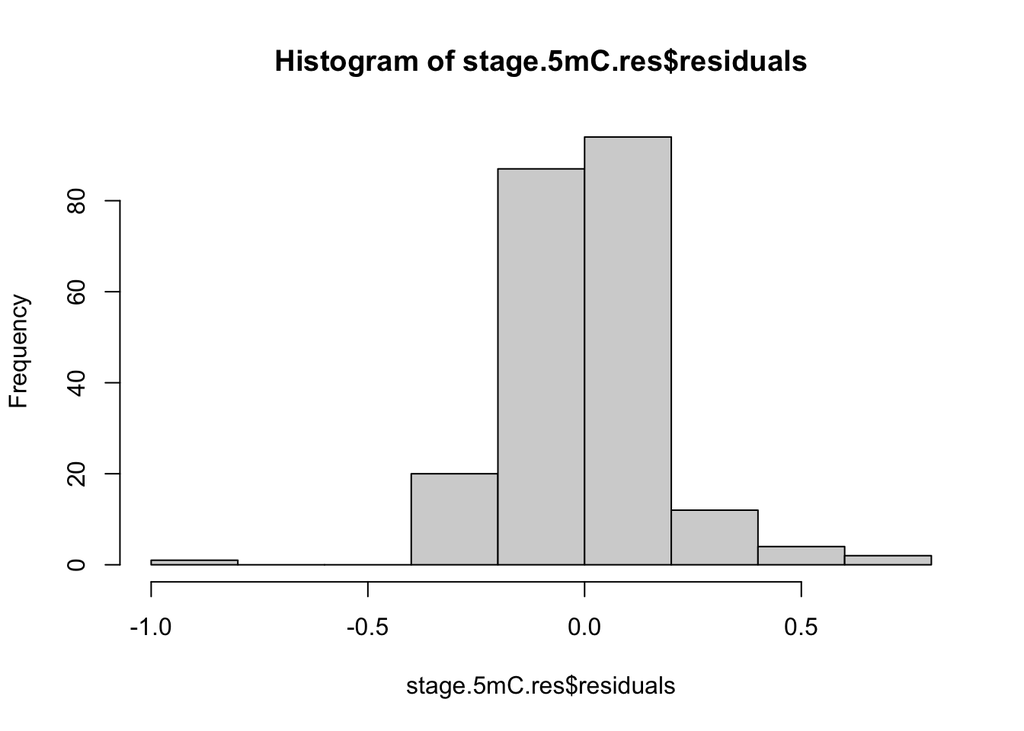

```r
hist(stage.5mC.res$residuals)
```

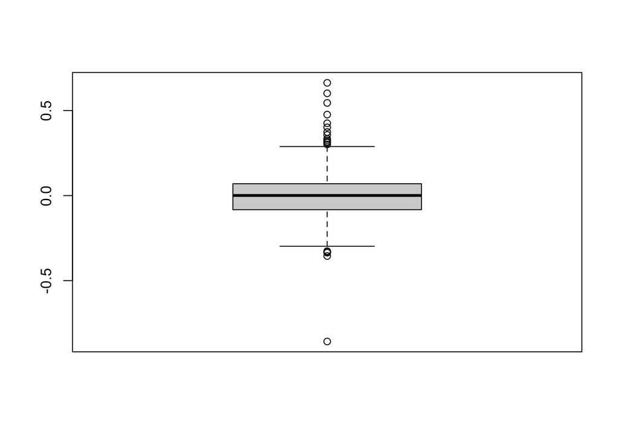

```r
boxplot(stage.5mC.res$residuals)
```

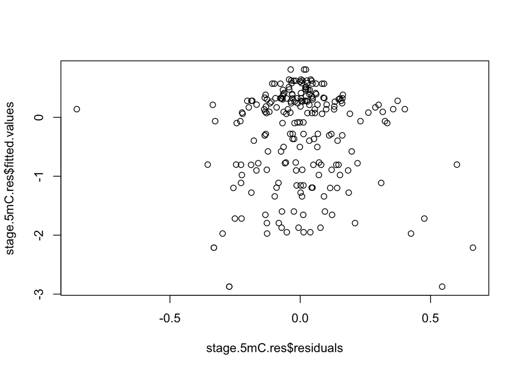

```r
plot(stage.5mC.res$residuals, stage.5mC.res$fitted.values)
```

```r
Tukey.ph <- TukeyHSD(stage.5mC.res)

summary_stats.devo.27 <- devo.27.stages %>%
  group_by(Species, Stage, Development) %>%
  summarize(
    mean_5mC = mean(rel.percent.5mC, na.rm = TRUE),
    sem_5mC = sd(rel.percent.5mC, na.rm = TRUE) / sqrt(n()),
    .groups = 'drop'
  )

Fig1 <- summary_stats.devo.27 %>%
  ggplot(aes(x = Development, y = mean_5mC, group = Species, color = Species)) +
  geom_line(aes(linetype = Species), size = 1) +  # Line connecting mean points
  geom_point(size = 3) +  # Mean points
  geom_errorbar(aes(ymin = mean_5mC - sem_5mC, ymax = mean_5mC + sem_5mC), width = 0.2) +  # SEM bars
  labs(
    x = "Stage",
    y = "Mean Relative % of 5mC"
  ) +
  scale_color_npg()+
  scale_fill_npg()+
  theme_classic() +
  theme(axis.text.x = element_text(angle = 45, hjust = 1))  # Rotate x-axis labels for better readability
```

DNA Hydroxymethylation 5hmC Quantification

Kit: Methylflash Hydroxymethylated DNA quantificiation Kit (Fluorometric) (Reference: P-1037) https://www.epigentek.com/docs/P-1037.pdf

Relative Quantification: To determine the relative hydroxymethylation status of two different DNA samples, simple calculation for the precentage of 5-hmC in your total DNA can be carried out using the following formula:

Relative %5hmC = ((Sample RFU - HF4 RFU)/ input DNA ng) / ((HF5 RFU - HF4 RFU)x 5 /amount of input positive control (HF5) in ng)

S is the amount of input sample DNA in ng. P is the amount of input positive control (HF5) in ng.

Acropora hyacinthus

```r
ahya.5hmC <- read.csv("RAnalysis/data/Ahyacinthus_5hmC.csv",  na.strings = "NA")

str(ahya.5hmC)
```

```
## 'data.frame':    114 obs. of  9 variables:
##  $ Stage         : chr  "Sperm" "Sperm" "Sperm" "Oocytes" ...
##  $ Development   : chr  "Sperm" "Sperm" "Sperm" "Oocytes" ...
##  $ HPF           : chr  "0" "0" "0" "0" ...
##  $ Species       : chr  "A. hyacinthus" "A. hyacinthus" "A. hyacinthus" "A. hyacinthus" ...
##  $ Mark          : chr  "5hmC" "5hmC" "5hmC" "5hmC" ...
##  $ Temperature   : int  27 27 27 27 27 27 27 27 27 27 ...
##  $ Replicate.Bio : chr  "Rep1" "Rep2" "Rep3" "Rep1" ...
##  $ Fluoro.530.590: int  59 60 68 67 56 64 74 65 68 58 ...
##  $ DNA.ng        : int  149 297 301 100 100 100 100 100 100 100 ...
```

```r
stnds.ahya.5hmC <- ahya.5hmC %>% filter(Species=="Standard") %>%
  group_by(Stage) %>%
  summarize(mean.RFU=mean(Fluoro.530.590))

ahya.5hmC <- ahya.5hmC %>% filter(Species=="A. hyacinthus")

HF4.RFU.ahya.5hmC <- stnds.ahya.5hmC$mean.RFU[[1]]
HF5.RFU.ahya.5hmC <- stnds.ahya.5hmC$mean.RFU[[2]]
HF5.ng.ahya.5hmC <- 10

ahya.5hmC$rel.percent.5mC <- (((ahya.5hmC$Fluoro.530.590 -HF4.RFU.ahya.5hmC )/ ahya.5hmC$DNA.ng) / ((HF5.RFU.ahya.5hmC - HF4.RFU.ahya.5hmC)* 5 /HF5.ng.ahya.5hmC))*100

ahya.5hmC <- ahya.5hmC %>%
filter(Temperature ==27)
```

Acropora cytherea 5hmC

```r
acyth.5hmC <- read.csv("RAnalysis/data/Acytherea_5hmC.csv",  na.strings = "NA")

str(acyth.5hmC)
```

```
## 'data.frame':    69 obs. of  9 variables:
##  $ Stage         : chr  "Sperm" "Sperm" "Sperm" "Oocytes" ...
##  $ Development   : chr  "Sperm" "Sperm" "Sperm" "Oocytes" ...
##  $ HPF           : chr  "0" "" "" "" ...
##  $ Species       : chr  "A. cytherea" "A. cytherea" "A. cytherea" "A. cytherea" ...
##  $ Mark          : chr  "5hmC" "5hmC" "5hmC" "5hmC" ...
##  $ Temperature   : int  27 27 27 27 27 27 27 27 27 27 ...
##  $ Replicate.Bio : chr  "Rep1" "Rep2" "Rep3" "Rep1" ...
##  $ Fluoro.530.590: int  16 15 15 65 13 15 123 400 23 40 ...
##  $ DNA.ng        : int  156 114 140 152 122 94 111 99 84 100 ...
```

```r
stnds.acyth.5hmC <- acyth.5hmC %>% filter(Species=="Standard") %>%
  group_by(Stage) %>%
  summarize(mean.RFU=mean(Fluoro.530.590))

acyth.5hmC <- acyth.5hmC %>% filter(Species=="A. cytherea")

HF4.RFU.acyth <- stnds.acyth.5hmC$mean.RFU[[1]]
HF5.RFU.acyth <- stnds.acyth.5hmC$mean.RFU[[2]]
HF5.ng.acyth <- 10

acyth.5hmC$rel.percent.5mC <- (((acyth.5hmC$Fluoro.530.590 -HF4.RFU.acyth )/ acyth.5hmC$DNA.ng) / ((HF5.RFU.acyth - HF4.RFU.acyth)* 5 /HF5.ng.acyth))*100

acyth.5hmC <- acyth.5hmC %>%
filter(Temperature ==27)
```

Acropora pulchra 5hmC

```r
apul.5hmC <- read.csv("RAnalysis/data/Apulchra_5hmC.csv",  na.strings = "NA")

str(apul.5hmC)
```

```
## 'data.frame':    91 obs. of  9 variables:
##  $ Stage         : chr  "Sperm" "Sperm" "Sperm" "Sperm" ...
##  $ Development   : chr  "Sperm" "Sperm" "Sperm" "Sperm" ...
##  $ HPF           : chr  "0" "0" "0" "0" ...
##  $ Species       : chr  "A. pulchra" "A. pulchra" "A. pulchra" "A. pulchra" ...
##  $ Mark          : chr  "5hmC" "5hmC" "5hmC" "5hmC" ...
##  $ Temperature   : int  27 27 27 27 27 27 27 27 27 27 ...
##  $ Replicate.Bio : chr  "Rep1" "Rep2" "Rep3" "Rep4" ...
##  $ Fluoro.530.590: int  34 48 38 33 236 18 24 21 23 26 ...
##  $ DNA.ng        : int  104 128 128 108 116 116 96 96 123 115 ...
```

```r
stnds.apul.5hmC <- apul.5hmC %>% filter(Species=="Standard") %>%
  group_by(Stage) %>%
  summarize(mean.RFU=mean(Fluoro.530.590))

apul.5hmC <- apul.5hmC %>% filter(Species=="A. pulchra")

HF4.RFU.apul <- stnds.apul.5hmC$mean.RFU[[1]]
HF5.RFU.apul <- stnds.apul.5hmC$mean.RFU[[2]]
HF5.ng.apul <- 10

apul.5hmC$rel.percent.5mC <- (((apul.5hmC$Fluoro.530.590 -HF4.RFU.apul)/ apul.5hmC$DNA.ng) / ((HF5.RFU.apul - HF4.RFU.apul)* 5 /HF5.ng.apul))*100

apul.5hmC <- apul.5hmC %>%
filter(Temperature ==27)
```

Acropora retusa 5hmC

```r
aret.5hmC <- read.csv("RAnalysis/data/Aretusa_5hmC.csv",  na.strings = "NA")

str(aret.5hmC)
```

```
## 'data.frame':    102 obs. of  9 variables:
##  $ Stage         : chr  "Sperm" "Sperm" "Sperm" "Sperm" ...
##  $ Development   : chr  "Sperm" "Sperm" "Sperm" "Sperm" ...
##  $ HPF           : chr  "0" "0" "0" "0" ...
##  $ Species       : chr  "A. retusa" "A. retusa" "A. retusa" "A. retusa" ...
##  $ Mark          : chr  "5hmC" "5hmC" "5hmC" "5hmC" ...
##  $ Temperature   : int  27 27 27 27 27 27 27 27 27 27 ...
##  $ Replicate.Bio : chr  "Rep1" "Rep2" "Rep3" "Rep4" ...
##  $ Fluoro.530.590: int  26 18 35 28 13 28 14 13 23 15 ...
##  $ DNA.ng        : int  116 124 143 143 76 102 100 100 96 96 ...
```

```r
stnds.aret.5hmC <- aret.5hmC %>% filter(Species=="Standard") %>%
  group_by(Stage) %>%
  summarize(mean.RFU=mean(Fluoro.530.590))

aret.5hmC <- aret.5hmC %>% filter(Species=="A. retusa")

HF4.RFU.aret <- stnds.aret.5hmC$mean.RFU[[1]]
HF5.RFU.aret <- stnds.aret.5hmC$mean.RFU[[2]]
HF5.ng.aret <- 10

aret.5hmC$rel.percent.5mC <- (((aret.5hmC$Fluoro.530.590 -HF4.RFU.aret )/ aret.5hmC$DNA.ng) / ((HF5.RFU.aret - HF4.RFU.aret)* 5 /HF5.ng.aret))*100

aret.5hmC <- aret.5hmC %>%
filter(Temperature ==27)
```

5hmC in all species at 27°C

```r
#examine only 27

all.species.5hmC <- rbind(ahya.5hmC, acyth.5hmC, apul.5hmC, aret.5hmC)
unique(all.species.5hmC$Stage)
```

```
##  [1] "Sperm"      "Oocytes"    "Stage 1 "   "Stage 2"    "Stage 3"
##  [6] "Stage 4"    "Stage 5"    "Stage 6"    "Stage 7"    "Stage 8"
## [11] "Stage 9"    "Stage 10"   "Stage 11"   "Stage 12"   "Stage 13"
## [16] "Stage 14"   "Stage 15"   "Stage 16"   "Stage 17"   "Stage 17.5"
## [21] "Stage 5.5"  "Stage 7.5"
```

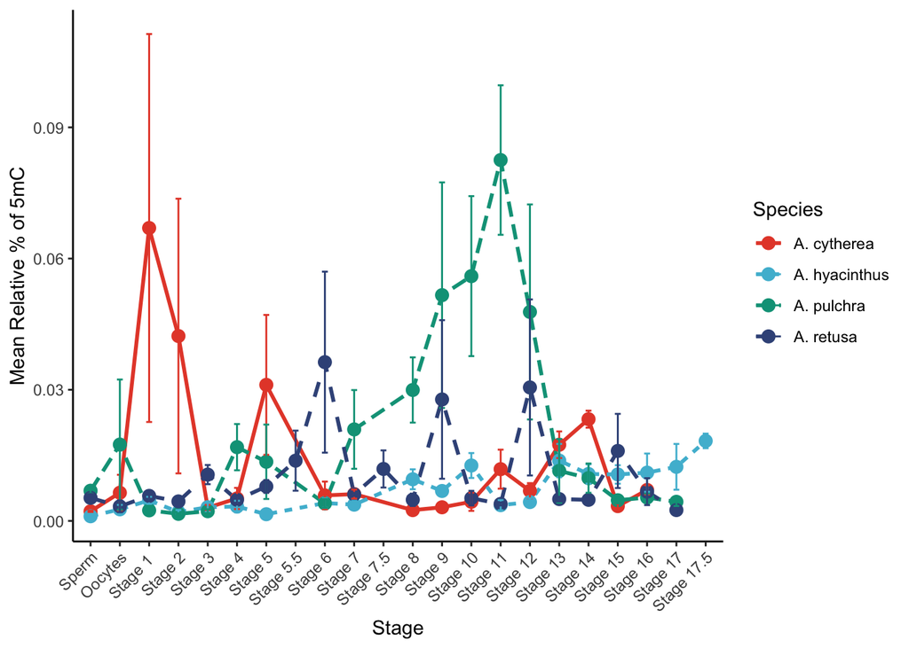

```r
devo.5hmC.27 <- all.species.5hmC %>%
  mutate(Stage = fct_relevel(Stage, "Sperm",      "Oocytes",   "Stage 1 ",   "Stage 2",
                             "Stage 3",    "Stage 4",    "Stage 5", "Stage 5.5",    "Stage 6",   "Stage 7",
                             "Stage 7.5", "Stage 8",    "Stage 9",    "Stage 10",   "Stage 11",   "Stage 12",
                             "Stage 13",   "Stage 14",  "Stage 15",   "Stage 16",   "Stage 17",   "Stage 17.5"))

summary_stats.devo.27.5hmC <- devo.5hmC.27 %>%
  group_by(Species, Stage, Development) %>%
  summarize(
    mean_5mC = mean(rel.percent.5mC, na.rm = TRUE),
    sem_5mC = sd(rel.percent.5mC, na.rm = TRUE) / sqrt(n()),
    .groups = 'drop'
  )

summary_stats.devo.27.5hmC %>%
  ggplot(aes(x = Stage, y = mean_5mC, group = Species, color = Species)) +
  geom_line(aes(linetype = Species), size = 1) +  # Line connecting mean points
  geom_point(size = 3) +  # Mean points
  geom_errorbar(aes(ymin = mean_5mC - sem_5mC, ymax = mean_5mC + sem_5mC), width = 0.2) +  # SEM bars
  labs(
    x = "Stage",
    y = "Mean Relative % of 5mC"
  ) +
  scale_color_npg()+
  scale_fill_npg()+
  theme_classic() +
  theme(axis.text.x = element_text(angle = 45, hjust = 1))  # Rotate x-axis labels for better readability
```

Reduce to commonly sampled timepoints and analyze with ANOVA

```r
devo.5hmC.27.stages <- devo.5hmC.27 %>%
  filter(!Stage == "Stage 5.5") %>%
  filter(!Stage == "Stage 7.5") %>%
  filter(!Stage == "Stage 12")%>%
  filter(!Stage == "Stage 17")%>%
  filter(!Stage == "Stage 17.5")

str(devo.5hmC.27.stages)
```

```
## 'data.frame':    238 obs. of  10 variables:
##  $ Stage          : Factor w/ 22 levels "Sperm","Oocytes",..: 1 1 1 2 2 2 3 3 3 4 ...
##  $ Development    : chr  "Sperm" "Sperm" "Sperm" "Oocytes" ...
##  $ HPF            : chr  "0" "0" "0" "0" ...
##  $ Species        : chr  "A. hyacinthus" "A. hyacinthus" "A. hyacinthus" "A. hyacinthus" ...
##  $ Mark           : chr  "5hmC" "5hmC" "5hmC" "5hmC" ...
##  $ Temperature    : int  27 27 27 27 27 27 27 27 27 27 ...
##  $ Replicate.Bio  : chr  "Rep1" "Rep2" "Rep3" "Rep1" ...
##  $ Fluoro.530.590 : int  59 60 68 67 56 64 74 65 68 58 ...
##  $ DNA.ng         : int  149 297 301 100 100 100 100 100 100 100 ...
##  $ rel.percent.5mC: num  0.001098 0.000654 0.00146 0.004089 0.000716 ...
```

```r
devo.5hmC.27.stages$Species <- as.factor(devo.5hmC.27.stages$Species)

unique(devo.5hmC.27.stages$Stage)
```

```
##  [1] Sperm    Oocytes  Stage 1  Stage 2  Stage 3  Stage 4  Stage 5  Stage 6
##  [9] Stage 7  Stage 8  Stage 9  Stage 10 Stage 11 Stage 13 Stage 14 Stage 15
## [17] Stage 16
## 22 Levels: Sperm Oocytes Stage 1  Stage 2 Stage 3 Stage 4 Stage 5 ... Stage 17.5
```

```r
unique(devo.5hmC.27.stages$Development)
```

```
##  [1] "Sperm"             "Oocytes"           "Fertilized oocyte"
##  [4] "4 cells"           "8 cells"           "Morula"
##  [7] "Prawn Chip"        "Blastula"          "Late Blastula"
## [10] "Early Bowl"        "Bowl"              "Blastulation end"
## [13] "Gastrula"          "Early tear drop"   "Tear drop"
## [16] "Late tear drop"    "Early elongated"
```

```r
devo.5hmC.27.stages <- devo.5hmC.27.stages %>%
  mutate(Development = fct_relevel(Development, "Sperm", "Oocytes", "Fertilized oocyte", "4 cells", "8 cells", "Morula",          "Prawn Chip", "Blastula", "Late Blastula", "Early Bowl", "Bowl", "Blastulation end", "Gastrula", "Early tear drop",
"Tear drop", "Late tear drop", "Early elongated"))

stage.5hmC.res <- aov(log10(rel.percent.5mC) ~ Stage*Species, data= devo.5hmC.27.stages)
summary(stage.5hmC.res)
```

```
##                Df Sum Sq Mean Sq F value   Pr(>F)
## Stage          16  6.644  0.4152   3.962 2.70e-06 ***
## Species         3  2.574  0.8579   8.185 4.17e-05 ***
## Stage:Species  48 25.810  0.5377   5.130 2.29e-15 ***
## Residuals     162 16.979  0.1048
## ---
## Signif. codes:  0 '***' 0.001 '**' 0.01 '*' 0.05 '.' 0.1 ' ' 1
## 8 observations deleted due to missingness
```

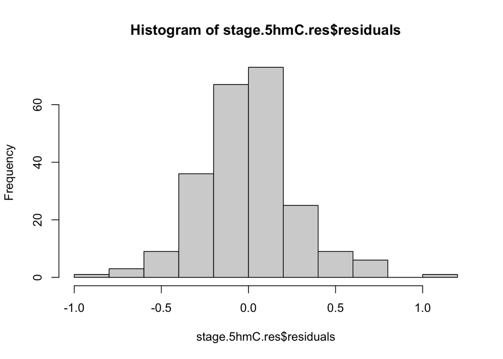

```r
hist(stage.5hmC.res$residuals)
```

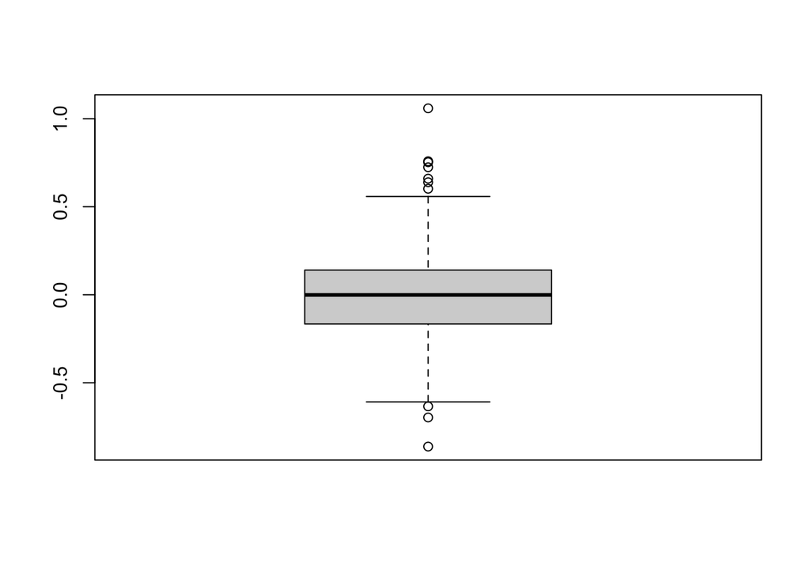

```r
boxplot(stage.5hmC.res$residuals)
```

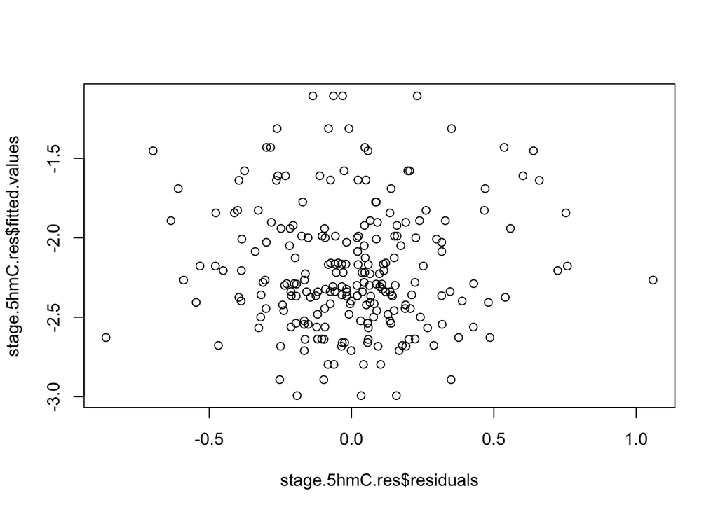

```r
plot(stage.5hmC.res$residuals, stage.5hmC.res$fitted.values)
```

```r
Tukey.ph.5hmC <- TukeyHSD(stage.5hmC.res)

summary_stats.5hmC.27 <- devo.5hmC.27.stages %>%
  group_by(Species, Stage, Development) %>%
  summarize(
    mean_5mC = mean(rel.percent.5mC, na.rm = TRUE),
    sem_5mC = sd(rel.percent.5mC, na.rm = TRUE) / sqrt(n()),
    .groups = 'drop'
  )

Fig2 <- summary_stats.5hmC.27 %>%
  ggplot(aes(x = Development, y = mean_5mC, group = Species, color = Species)) +
  geom_line(aes(linetype = Species), size = 1) +  # Line connecting mean points
  geom_point(size = 3) +  # Mean points
  geom_errorbar(aes(ymin = mean_5mC - sem_5mC, ymax = mean_5mC + sem_5mC), width = 0.2) +  # SEM bars
  labs(
    x = "Stage",
    y = "Mean Relative % of 5hmC"
  ) +
  scale_color_npg()+
  scale_fill_npg()+
  theme_classic() +
  theme(axis.text.x = element_text(angle = 45, hjust = 1))  # Rotate x-axis labels for better readability
```

DNA 5-Formylcytosine (5-fC) Quantification

Kit: Methylflash 5-Formylcytosine DNA quantificiation Kit (Colorimetric) (Reference: P-1041) https://www.epigentek.com/docs/P-1041.pdf

Relative Quantification: To determine the relative 5-fC status of two different DNA samples, simple calculation for the percentage of 5-fC in your total DNA can be carried out using the following formula:

Relative %5fC = ((Sample OD - NC OD)/ input DNA ng) / ((PC OD - NC OD) /amount of input positive control (PC) in ng)

Acropora hyacinthus 5fC

```r
ahya.5fC <- read.csv("RAnalysis/data/Ahyacinthus_5fC.csv",  na.strings = "NA")

str(ahya.5fC)
```

```
## 'data.frame':    114 obs. of  9 variables:
##  $ Stage        : chr  "Sperm" "Sperm" "Sperm" "Oocytes" ...
##  $ Development  : chr  "Sperm" "Sperm" "Sperm" "Oocytes" ...
##  $ HPF          : chr  "0" "0" "0" "0" ...
##  $ Species      : chr  "A. hyacinthus" "A. hyacinthus" "A. hyacinthus" "A. hyacinthus" ...
##  $ Mark         : chr  "5fC" "5fC" "5fC" "5fC" ...
##  $ Temperature  : int  27 27 27 27 27 27 27 27 27 27 ...
##  $ Replicate.Bio: chr  "Rep1" "Rep2" "Rep3" "Rep1" ...
##  $ Abs.450      : num  0.272 0.276 0.278 0.274 0.276 0.279 0.273 0.276 0.279 0.279 ...
##  $ DNA.ng       : int  300 300 300 300 300 300 152 264 264 144 ...
```

```r
stnds.ahya.5fC <- ahya.5fC %>% filter(Species=="Standard") %>%
  group_by(Stage) %>%
  summarize(mean.RFU=mean(Abs.450))

ahya.5fC <- ahya.5fC %>% filter(Species=="A. hyacinthus")

NC.OD.ahya <- stnds.ahya.5fC$mean.RFU[[1]]
PC.OD.ahya <- stnds.ahya.5fC$mean.RFU[[2]]
PC.ng.ahya <- 0.2

ahya.5fC$rel.percent.5fC <- (((ahya.5fC$Abs.450 -NC.OD.ahya )/ ahya.5fC$DNA.ng) / ((PC.OD.ahya - NC.OD.ahya)/PC.ng.ahya))*100

ahya.5fC <- ahya.5fC %>%
filter(Temperature ==27)
```

Acropora cytherea 5fC

```r
acyth.5fC <- read.csv("RAnalysis/data/Acytherea_5fC.csv",  na.strings = "NA")

str(acyth.5fC)
```

```
## 'data.frame':    75 obs. of  9 variables:
##  $ Stage        : chr  "Sperm" "Sperm" "Sperm" "Oocytes" ...
##  $ Development  : chr  "Sperm" "Sperm" "Sperm" "Oocytes" ...
##  $ HPF          : chr  "0" "" "" "" ...
##  $ Species      : chr  "A. cytherea" "A. cytherea" "A. cytherea" "A. cytherea" ...
##  $ Mark         : chr  "5fC" "5fC" "5fC" "5fC" ...
##  $ Temperature  : int  27 27 27 27 27 27 27 27 27 27 ...
##  $ Replicate.Bio: chr  "Rep1" "Rep2" "Rep3" "Rep1" ...
##  $ Abs.450      : num  0.313 0.302 0.356 0.3 0.266 0.283 0.28 0.287 0.272 0.31 ...
##  $ DNA.ng       : int  234 228 210 288 244 216 222 231 168 200 ...
```

```r
stnds.acyth.5fC <- acyth.5fC %>% filter(Species=="Standard") %>%
  group_by(Stage) %>%
  summarize(mean.RFU=mean(Abs.450))

acyth.5fC <- acyth.5fC %>% filter(Species=="A. cytherea")

NC.OD.acyth <- stnds.acyth.5fC$mean.RFU[[1]]
PC.OD.acyth <- stnds.acyth.5fC$mean.RFU[[2]]
PC.ng.acyth <- 0.2

acyth.5fC$rel.percent.5fC <- (((acyth.5fC$Abs.450 -NC.OD.acyth )/ acyth.5fC$DNA.ng) / ((PC.OD.acyth - NC.OD.acyth)/PC.ng.acyth))*100

acyth.5fC <- acyth.5fC %>%
filter(Temperature ==27)
```

Acropora pulchra 5fC

```r
apul.5fC <- read.csv("RAnalysis/data/Apulchra_5fC.csv",  na.strings = "NA")

str(apul.5fC)
```

```
## 'data.frame':    97 obs. of  9 variables:
##  $ Stage        : chr  "Sperm" "Sperm" "Sperm" "Sperm" ...
##  $ Development  : chr  "Sperm" "Sperm" "Sperm" "Sperm" ...
##  $ HPF          : chr  "0" "0" "0" "0" ...
##  $ Species      : chr  "A. pulchra" "A. pulchra" "A. pulchra" "A. pulchra" ...
##  $ Mark         : chr  "5fC" "5fC" "5fC" "5fC" ...
##  $ Temperature  : int  27 27 27 27 27 27 27 27 27 27 ...
##  $ Replicate.Bio: chr  "Rep1" "Rep2" "Rep3" "Rep4" ...
##  $ Abs.450      : num  0.045 0.044 0.047 0.044 0.045 0.046 0.047 0.046 0.048 0.044 ...
##  $ DNA.ng       : int  300 300 300 300 128 300 184 184 300 160 ...
```

```r
stnds.apul.5fC <- apul.5fC %>% filter(Species=="Standard") %>%
  group_by(Stage) %>%
  summarize(mean.RFU=mean(Abs.450))

apul.5fC <- apul.5fC %>% filter(Species=="A. pulchra")

NC.OD.apul <- stnds.apul.5fC$mean.RFU[[1]]
PC.OD.apul <- stnds.apul.5fC$mean.RFU[[2]]
PC.ng.apul <- 0.2

apul.5fC$rel.percent.5fC <- (((apul.5fC$Abs.450 -NC.OD.apul )/ apul.5fC$DNA.ng) / ((PC.OD.apul - NC.OD.apul)/PC.ng.apul))*100

apul.5fC <- apul.5fC %>%
filter(Temperature ==27)
```

Acropora retusa 5fC

```r
aret.5fC <- read.csv("RAnalysis/data/Aretusa_5fC.csv",  na.strings = "NA")

str(aret.5fC)
```

```
## 'data.frame':    75 obs. of  9 variables:
##  $ Stage        : chr  "Sperm" "Sperm" "Sperm" "Oocytes" ...
##  $ Development  : chr  "Sperm" "Sperm" "Sperm" "Oocytes" ...
##  $ HPF          : chr  "0" "0" "0" "0" ...
##  $ Species      : chr  "A. retusa" "A. retusa" "A. retusa" "A. retusa" ...
##  $ Mark         : chr  "5fC" "5fC" "5fC" "5fC" ...
##  $ Temperature  : int  27 27 27 27 27 27 27 27 27 27 ...
##  $ Replicate.Bio: chr  "Rep1" "Rep2" "Rep3" "Rep1" ...
##  $ Abs.450      : num  0.281 0.309 0.253 0.287 0.324 0.294 0.275 0.311 0.292 0.263 ...
##  $ DNA.ng       : int  294 311 286 152 238 300 192 192 136 232 ...
```

```r
stnds.aret.5fC <- aret.5fC %>% filter(Species=="Standard") %>%
  group_by(Stage) %>%
  summarize(mean.RFU=mean(Abs.450))

aret.5fC <- aret.5fC %>% filter(Species=="A. retusa")

NC.OD.aret <- stnds.aret.5fC$mean.RFU[[1]]
PC.OD.aret <- stnds.aret.5fC$mean.RFU[[2]]
PC.ng.aret <- 0.2

aret.5fC$rel.percent.5fC <- (((aret.5fC$Abs.450 -NC.OD.aret )/ aret.5fC$DNA.ng) / ((PC.OD.aret - NC.OD.aret)/PC.ng.aret))*100

aret.5fC <- aret.5fC %>%
filter(Temperature ==27)
```

5fC in all species at 27°C

```r
#examine only 27

all.species.5fC <- rbind(ahya.5fC, acyth.5fC, apul.5fC, aret.5fC)
unique(all.species.5fC$Stage)
```

```
##  [1] "Sperm"      "Oocytes"    "Stage 1 "   "Stage 2"    "Stage 3"
##  [6] "Stage 4"    "Stage 5"    "Stage 6"    "Stage 7"    "Stage 8"
## [11] "Stage 9"    "Stage 10"   "Stage 11"   "Stage 12"   "Stage 13"
## [16] "Stage 14"   "Stage 15"   "Stage 16"   "Stage 17"   "Stage 17.5"
```

```r
devo.5fC.27 <- all.species.5fC %>%
  mutate(Stage = fct_relevel(Stage, "Sperm",      "Oocytes",   "Stage 1 ",   "Stage 2",
                             "Stage 3",    "Stage 4",    "Stage 5", "Stage 5.5",    "Stage 6",   "Stage 7",
                             "Stage 7.5", "Stage 8",    "Stage 9",    "Stage 10",   "Stage 11",   "Stage 12",
                             "Stage 13",   "Stage 14",  "Stage 15",   "Stage 16",   "Stage 17",   "Stage 17.5"))
```

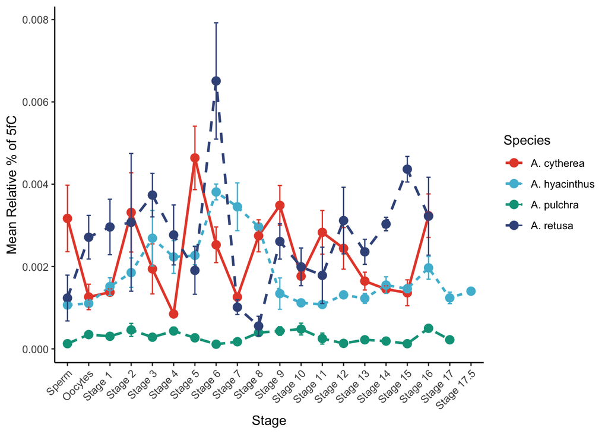

```r
summary_stats.devo.27.5fC <- devo.5fC.27 %>%
  group_by(Species, Stage, Development) %>%
  summarize(
    mean_5mC = mean(rel.percent.5fC, na.rm = TRUE),
    sem_5mC = sd(rel.percent.5fC, na.rm = TRUE) / sqrt(n()),
    .groups = 'drop'
  )

summary_stats.devo.27.5fC %>%
  ggplot(aes(x = Stage, y = mean_5mC, group = Species, color = Species)) +
  geom_line(aes(linetype = Species), size = 1) +  # Line connecting mean points
  geom_point(size = 3) +  # Mean points
  geom_errorbar(aes(ymin = mean_5mC - sem_5mC, ymax = mean_5mC + sem_5mC), width = 0.2) +  # SEM bars
  labs(
    x = "Stage",
    y = "Mean Relative % of 5fC"
  ) +
  scale_color_npg()+
  scale_fill_npg()+
  theme_classic() +
  theme(axis.text.x = element_text(angle = 45, hjust = 1))  # Rotate x-axis labels for better readability
```

Reduce to commonly sampled timepoints and analyze with ANOVA

```r
devo.5fC.27.stages <- devo.5fC.27 %>%
  filter(!Stage == "Stage 5.5") %>%
  filter(!Stage == "Stage 7.5") %>%
  filter(!Stage == "Stage 12")%>%
  filter(!Stage == "Stage 17")%>%
  filter(!Stage == "Stage 17.5")

str(devo.5fC.27.stages)
```

```
## 'data.frame':    221 obs. of  10 variables:
##  $ Stage          : Factor w/ 20 levels "Sperm","Oocytes",..: 1 1 1 2 2 2 3 3 3 4 ...
##  $ Development    : chr  "Sperm" "Sperm" "Sperm" "Oocytes" ...
##  $ HPF            : chr  "0" "0" "0" "0" ...
##  $ Species        : chr  "A. hyacinthus" "A. hyacinthus" "A. hyacinthus" "A. hyacinthus" ...
##  $ Mark           : chr  "5fC" "5fC" "5fC" "5fC" ...
##  $ Temperature    : int  27 27 27 27 27 27 27 27 27 27 ...
##  $ Replicate.Bio  : chr  "Rep1" "Rep2" "Rep3" "Rep1" ...
##  $ Abs.450        : num  0.272 0.276 0.278 0.274 0.276 0.279 0.273 0.276 0.279 0.279 ...
##  $ DNA.ng         : int  300 300 300 300 300 300 152 264 264 144 ...
##  $ rel.percent.5fC: num  0.000944 0.001091 0.001165 0.001018 0.001091 ...
```

```r
devo.5fC.27.stages$Species <- as.factor(devo.5fC.27.stages$Species)

unique(devo.5fC.27.stages$Stage)
```

```
##  [1] Sperm    Oocytes  Stage 1  Stage 2  Stage 3  Stage 4  Stage 5  Stage 6
##  [9] Stage 7  Stage 8  Stage 9  Stage 10 Stage 11 Stage 13 Stage 14 Stage 15
## [17] Stage 16
## 20 Levels: Sperm Oocytes Stage 1  Stage 2 Stage 3 Stage 4 Stage 5 ... Stage 17.5
```

```r
unique(devo.5fC.27.stages$Development)
```

```
##  [1] "Sperm"             "Oocytes"           "Fertilized oocyte"
##  [4] "4 cells"           "8 cells"           "Morula"
##  [7] "Prawn Chip"        "Blastula"          "Late Blastula"
## [10] "Early Bowl"        "Bowl"              "Blastulation end"
## [13] "Gastrula"          "Early tear drop"   "Tear drop"
## [16] "Late tear drop"    "Early elongated"
```

```r
devo.5fC.27.stages <- devo.5fC.27.stages %>%
  mutate(Development = fct_relevel(Development, "Sperm", "Oocytes", "Fertilized oocyte", "4 cells", "8 cells", "Morula",          "Prawn Chip", "Blastula", "Late Blastula", "Early Bowl", "Bowl", "Blastulation end", "Gastrula", "Early tear drop",
"Tear drop", "Late tear drop", "Early elongated"))

stage.5fC.res <- aov(log10(rel.percent.5fC) ~ Stage*Species, data= devo.5fC.27.stages)
summary(stage.5fC.res)
```

```
##                Df Sum Sq Mean Sq F value   Pr(>F)
## Stage          16   2.53   0.158   2.694 0.000914 ***
## Species         3  38.85  12.950 220.686  < 2e-16 ***
## Stage:Species  48   8.50   0.177   3.019 1.87e-07 ***
## Residuals     146   8.57   0.059
## ---
## Signif. codes:  0 '***' 0.001 '**' 0.01 '*' 0.05 '.' 0.1 ' ' 1
## 7 observations deleted due to missingness
```

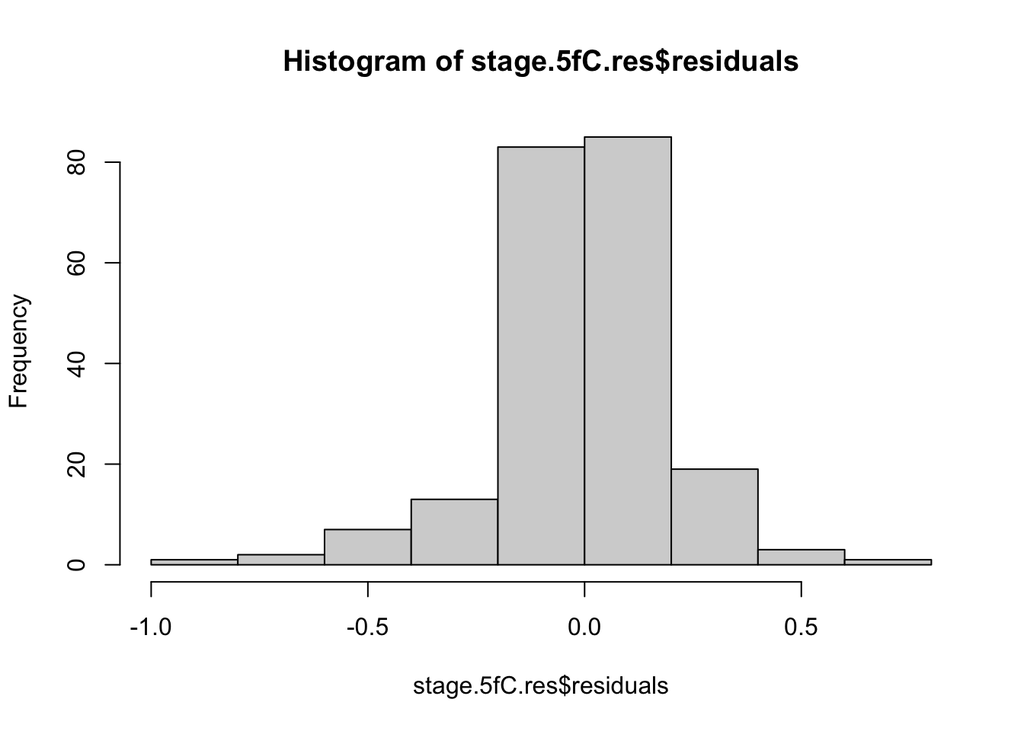

```r
hist(stage.5fC.res$residuals)
```

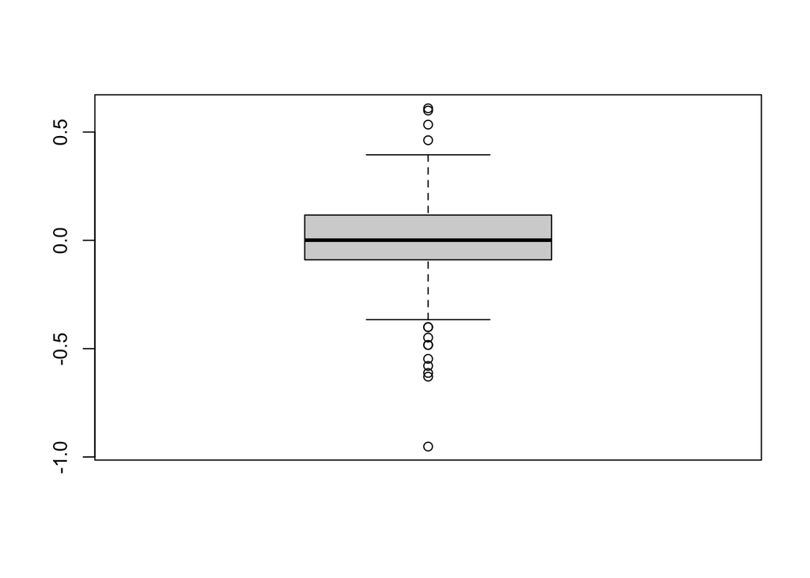

```r
boxplot(stage.5fC.res$residuals)
```

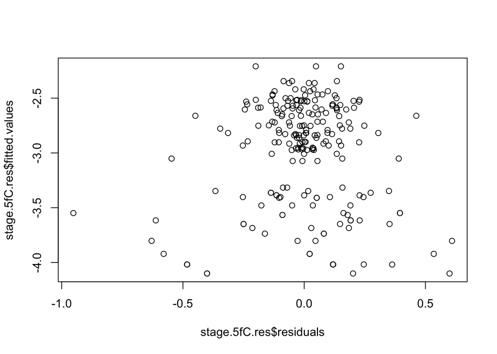

```r
plot(stage.5fC.res$residuals, stage.5fC.res$fitted.values)
```

```r
Tukey.ph.5fC <- TukeyHSD(stage.5fC.res)

summary_stats.5fC.27 <- devo.5fC.27.stages %>%
  group_by(Species, Stage, Development) %>%
  summarize(
    mean_5mC = mean(rel.percent.5fC, na.rm = TRUE),
    sem_5mC = sd(rel.percent.5fC, na.rm = TRUE) / sqrt(n()),
    .groups = 'drop'
  )

Fig3 <- summary_stats.5fC.27 %>%
  ggplot(aes(x = Development, y = mean_5mC, group = Species, color = Species)) +
  geom_line(aes(linetype = Species), size = 1) +  # Line connecting mean points
  geom_point(size = 3) +  # Mean points
  geom_errorbar(aes(ymin = mean_5mC - sem_5mC, ymax = mean_5mC + sem_5mC), width = 0.2) +  # SEM bars
  labs(
    x = "Stage",
    y = "Mean Relative % of 5fC"
  ) +
  scale_color_npg()+
  scale_fill_npg()+
  theme_classic() +
  theme(axis.text.x = element_text(angle = 45, hjust = 1))  # Rotate x-axis labels for better readability
```

Plot all together

```r
all <- rbind(summary_stats.devo.27, summary_stats.5hmC.27, summary_stats.5fC.27)

# all %>%
#   ggplot(aes(x = Development, y = mean_5mC, group = Species, color = Species)) +
#   geom_line(aes(linetype = Species), size = 1) +  # Line connecting mean points
#   geom_point(size = 3) +  # Mean points
#   geom_errorbar(aes(ymin = mean_5mC - sem_5mC, ymax = mean_5mC + sem_5mC), width = 0.2) +  # SEM bars
#   labs(
#     x = "Stage",
#     y = "Mean Relative % of 5fC"
#   ) +
#   scale_color_npg()+
#   scale_fill_npg()+
#   facet_grid(Mark)+
#   theme_classic() +
#   theme(axis.text.x = element_text(angle = 45, hjust = 1))  # Rotate x-axis labels for better readability
```